# BIOS 7323 Lab 1

2018-08-27

### Objective

In this lab you will learn how to organize and format survival data in R using packages from the [tidyverse](https://www.tidyverse.org/). You will need the packages `tidyverse`, `lubridate`, and `survival` and the data files `tonguecancer_long.csv` and `tonguecancer_baseline.csv`.

### Data Description

Information was collected from eighty males diagnosed with tongue cancer between Jan 1, 2001 and Dec 31, 2008. Each person was followed from diagnosis until death or the end of the study. Tumor DNA type, age, and race were also collected for each person at baseline. The data is modified from section 1.11 of Klein & Moeschberger (K&M) and is contained in two files.

`tonguecancer_long.csv`: longitudinal data set  
patid: patient ID  
date: date of record  
rectype: type of record (1=diagnosis, 9=death)

`tonguecancer_baseline.csv`: baseline characteristics  
patid: patient ID  
tumor: tumor DNA profile (1=aneuploid tumor, 2=diploid tumor)  
age: patient age in years  
race: race (1=white, 2=black, 3=asian, 4=other)

### Import the data

We can import the data using the `read_csv()` function which is part of the `readr` tidyverse package. The output object is a ‘tibble’. From the tibble [site](https://tibble.tidyverse.org/) – Tibbles are data.frames that are lazy and surly: they do less (i.e. they don’t change variable names or types, and don’t do partial matching) and complain more (e.g. when a variable does not exist)

```r
# longitudinal data (tonguecancer_long.csv)
dat_long <- read_csv('tonguecancer_long.csv')
# baseline data (tonguecancer_baseline.csv)
dat_base <- read_csv('tonguecancer_baseline.csv')
dat_long
```

```
## # A tibble: 133 x 3
##    patid date       rectype
##    <int> <chr>        <int>
##  1    56 3/13/2001        1
##  2    72 4/8/2001         1
##  3    56 4/17/2001        9
##  4    18 4/18/2001        1
##  5    52 5/2/2001         1
##  6     6 5/9/2001         1
##  7     6 8/8/2001         9
##  8    30 9/26/2001        1
##  9    15 10/7/2001        1
## 10    67 12/18/2001       1
## # ... with 123 more rows
```

The dat_long object has observations in chronological order. Let’s re-arrange by patient ID and look at the first few rows.

```r
#dat_long arranged by patid
arrange(dat_long, patid)
```

```
## # A tibble: 133 x 3
##    patid date       rectype
##    <int> <chr>        <int>
##  1     1 4/19/2003        1
##  2     1 4/26/2003        9
##  3     2 4/6/2007         1
##  4     2 4/27/2007        9
##  5     3 4/1/2004         1
##  6     3 4/22/2004        9
##  7     4 12/31/2007       1
##  8     4 1/28/2008        9
##  9     5 5/6/2008         1
## 10     5 7/15/2008        9
## # ... with 123 more rows
```

### Reshape and merge the data

Notice that dat_long dataset is in long format with multiple records per patid. We are interested in the time between diagnosis and death or censoring which is easier to calculate if the data is in wide format. The `spread()` function will put the dates into two columns based on the value of the `rectype` variable. We then `rename()` the columns and merge on the tumor type and demographic data using `left_join()`.

```r
( d1 <- tidyr::spread(dat_long, rectype, date) ) #reshape so dates are in two columns
```

```
## # A tibble: 80 x 3
##    patid `1`        `9`
##    <int> <chr>      <chr>
##  1     1 4/19/2003  4/26/2003
##  2     2 4/6/2007   4/27/2007
##  3     3 4/1/2004   4/22/2004
##  4     4 12/31/2007 1/28/2008
##  5     5 5/6/2008   7/15/2008
##  6     6 5/9/2001   8/8/2001
##  7     7 2/4/2005   5/6/2005
##  8     8 11/13/2007 3/4/2008
##  9     9 3/30/2005  7/20/2005
## 10    10 6/11/2004  11/26/2004
## # ... with 70 more rows
```

```r
( d2 <- dplyr::rename(d1, date1="1", date2="9") ) #renames new columns
```

```
## # A tibble: 80 x 3
##    patid date1      date2
##    <int> <chr>      <chr>
##  1     1 4/19/2003  4/26/2003
##  2     2 4/6/2007   4/27/2007
##  3     3 4/1/2004   4/22/2004
##  4     4 12/31/2007 1/28/2008
##  5     5 5/6/2008   7/15/2008
##  6     6 5/9/2001   8/8/2001
##  7     7 2/4/2005   5/6/2005
##  8     8 11/13/2007 3/4/2008
##  9     9 3/30/2005  7/20/2005
## 10    10 6/11/2004  11/26/2004
## # ... with 70 more rows
```

```r
( d3 <- dplyr::left_join(d2, dat_base) ) #merge on the tumor & demographic data
```

```
## # A tibble: 80 x 6
##    patid date1      date2      tumor   age  race
##    <int> <chr>      <chr>      <int> <int> <int>
##  1     1 4/19/2003  4/26/2003      1    43     3
##  2     2 4/6/2007   4/27/2007      1    57     3
##  3     3 4/1/2004   4/22/2004      1    46     3
##  4     4 12/31/2007 1/28/2008      1    43     4
##  5     5 5/6/2008   7/15/2008      1    63     4
##  6     6 5/9/2001   8/8/2001       1    67     4
##  7     7 2/4/2005   5/6/2005       1    51     2
##  8     8 11/13/2007 3/4/2008       1    60     2
##  9     9 3/30/2005  7/20/2005      1    42     2
## 10    10 6/11/2004  11/26/2004     1    51     1
## # ... with 70 more rows
```

```r
# Equivalently, do all 3 steps above in one line using pipes (%>%)
dat_wide <- spread(dat_long, rectype, date) %>% rename(date1="1", date2="9") %>% left_join(dat_base)
identical(d3, dat_wide)
```

```
## [1] TRUE
```

```r
dat_wide
```

```
## # A tibble: 80 x 6
##    patid date1      date2      tumor   age  race
##    <int> <chr>      <chr>      <int> <int> <int>
##  1     1 4/19/2003  4/26/2003      1    43     3
##  2     2 4/6/2007   4/27/2007      1    57     3
##  3     3 4/1/2004   4/22/2004      1    46     3
##  4     4 12/31/2007 1/28/2008      1    43     4
##  5     5 5/6/2008   7/15/2008      1    63     4
##  6     6 5/9/2001   8/8/2001       1    67     4
##  7     7 2/4/2005   5/6/2005       1    51     2
##  8     8 11/13/2007 3/4/2008       1    60     2
##  9     9 3/30/2005  7/20/2005      1    42     2
## 10    10 6/11/2004  11/26/2004     1    51     1
## # ... with 70 more rows
```

### Change data type and add labels

The `tumor` and `race` variables are currently ‘integer’ values. Let’s use `mutate()` and `recode_factor()` to convert them from ‘integer’ to ‘factor’ and add some labels.

```r
( dat_label <- dplyr::mutate(dat_wide,
       tumor=recode_factor(tumor, `1`="aneuploid", `2`="diploid"),
       race=recode_factor(race, `1`="white", `2`="black", `3`="asian", `4`="other") )
)
```

```
## # A tibble: 80 x 6
##    patid date1      date2      tumor       age race
##    <int> <chr>      <chr>      <fct>     <int> <fct>
##  1     1 4/19/2003  4/26/2003  aneuploid    43 asian
##  2     2 4/6/2007   4/27/2007  aneuploid    57 asian
##  3     3 4/1/2004   4/22/2004  aneuploid    46 asian
##  4     4 12/31/2007 1/28/2008  aneuploid    43 other
##  5     5 5/6/2008   7/15/2008  aneuploid    63 other
##  6     6 5/9/2001   8/8/2001   aneuploid    67 other
##  7     7 2/4/2005   5/6/2005   aneuploid    51 black
##  8     8 11/13/2007 3/4/2008   aneuploid    60 black
##  9     9 3/30/2005  7/20/2005  aneuploid    42 black
## 10    10 6/11/2004  11/26/2004 aneuploid    51 white
## # ... with 70 more rows
```

### Add event indicator and censoring date

Survival data has two parts, a time-to-event (e.g., the follow-up time for each patient) and an event indicator (did death occur?). Patients who did not experience the event have a *censored* time. In the tongue cancer data, death is indicated by a non-missing `date2` value. If `date2` is missing the time was censored at the end of the study. We use `mutate()` and `if_else()` [note the underscore!] to create an event indicator (0=censored, 1=death) and then replace the missing `date2` values with the end of study censoring date (12/31/2008) for those who did not die.

```r
# look at last 10 rows of dat_label
tail(dat_label, 10)
```

```
## # A tibble: 10 x 6
##    patid date1     date2     tumor     age race
##    <int> <chr>     <chr>     <fct>   <int> <fct>
##  1    71 2/26/2006 2/24/2008 diploid    46 asian
##  2    72 4/8/2001  6/1/2003  diploid    51 black
##  3    73 6/12/2003 12/1/2005 diploid    70 other
##  4    74 8/15/2004 2/3/2008  diploid    44 black
##  5    75 11/5/2008 <NA>      diploid    42 black
##  6    76 9/19/2007 <NA>      diploid    44 white
##  7    77 7/18/2007 <NA>      diploid    61 white
##  8    78 1/3/2007  <NA>      diploid    59 black
##  9    79 8/17/2005 <NA>      diploid    67 black
## 10    80 7/28/2004 <NA>      diploid    60 white
```

```r
# create (0/1) event indicator for death and add censoring date
dat_ind <- mutate(dat_label,
                    death=if_else(is.na(date2),0,1),
                    date2=if_else(death==0,"12/31/2008",date2) )

 # last 10 rows of dat_ind
tail(dat_ind, 10)
```

```
## # A tibble: 10 x 7
##    patid date1     date2      tumor     age race  death
##    <int> <chr>     <chr>      <fct>   <int> <fct> <dbl>
##  1    71 2/26/2006 2/24/2008  diploid    46 asian     1
##  2    72 4/8/2001  6/1/2003   diploid    51 black     1
##  3    73 6/12/2003 12/1/2005  diploid    70 other     1
##  4    74 8/15/2004 2/3/2008   diploid    44 black     1
##  5    75 11/5/2008 12/31/2008 diploid    42 black     0
##  6    76 9/19/2007 12/31/2008 diploid    44 white     0
##  7    77 7/18/2007 12/31/2008 diploid    61 white     0
##  8    78 1/3/2007  12/31/2008 diploid    59 black     0
##  9    79 8/17/2005 12/31/2008 diploid    67 black     0
## 10    80 7/28/2004 12/31/2008 diploid    60 white     0
```

### Create time-to-event and survival object

The next step is to calculate the survival time which is the difference between the diagnosis date and the death or censoring date.

The function `mdy()` from the `lubridate` package converts the `date1` and `date2` variables from ‘character’ to ‘date’ format. Then we take the difference to create a new variable called `stime`.

```r
( dat_final <- mutate(dat_ind, date1=mdy(date1), date2=mdy(date2), stime=date2-date1) )
```

```
## # A tibble: 80 x 8
##    patid date1      date2      tumor       age race  death stime
##    <int> <date>     <date>     <fct>     <int> <fct> <dbl> <time>
##  1     1 2003-04-19 2003-04-26 aneuploid    43 asian     1 "  7 days"
##  2     2 2007-04-06 2007-04-27 aneuploid    57 asian     1 " 21 days"
##  3     3 2004-04-01 2004-04-22 aneuploid    46 asian     1 " 21 days"
##  4     4 2007-12-31 2008-01-28 aneuploid    43 other     1 " 28 days"
##  5     5 2008-05-06 2008-07-15 aneuploid    63 other     1 " 70 days"
##  6     6 2001-05-09 2001-08-08 aneuploid    67 other     1 " 91 days"
##  7     7 2005-02-04 2005-05-06 aneuploid    51 black     1 " 91 days"
##  8     8 2007-11-13 2008-03-04 aneuploid    60 black     1 112 days
##  9     9 2005-03-30 2005-07-20 aneuploid    42 black     1 112 days
## 10    10 2004-06-11 2004-11-26 aneuploid    51 white     1 168 days
## # ... with 70 more rows
```

Finally we need to create a special type of R object called a ‘Surv’ which contains the two types of information needed for survival data (time-to-event and event indicator). A ‘Surv’ is actually a matrix with the survival times in the first column and the event indicator in the second column along with a few other attributes. When you print a Surv object, censored survival times will appear with a `+`.

```r
( S <- Surv(time=dat_final$stime, event=dat_final$death) )
```

```
##  [1]    7    21    21    28    70    91    91   112   112   168   182
## [12]  189   196   210   210   224   287   357   455   469   490   504
## [23]  511   539   637   651   672   700   728  1099  1169   427+  518+
## [34]  553+  560+  567+  609+  609+  616+  623+  651+  679+  707+  728+
## [45]  756+  763+  840+  917+ 1050+ 1617+ 1680+ 2800+    7    21    28
## [56]   35    35    56    84    91   126   161   182   189   210   294
## [67]  392   434   483   728   728   784   903  1267    56+  469+  532+
## [78]  728+ 1232+ 1617+
```

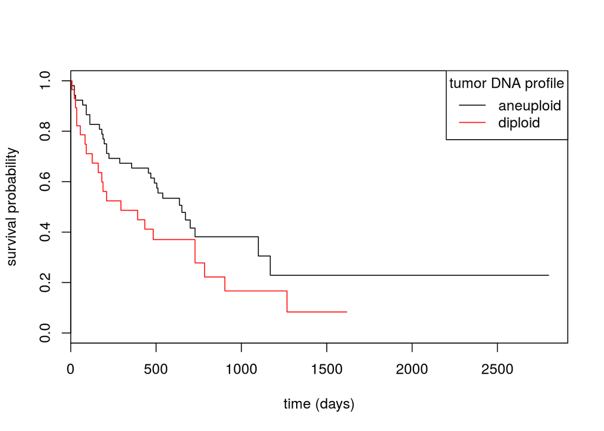

```r
#example - use Surv object to make a Kaplan-Meier plot
plot(survfit(S ~ tumor, data=dat_final),
     col=c(1,2), xlab="time (days)", ylab="survival probability")

legend("topright", title="tumor DNA profile", legend=c("aneuploid", "diploid"),
       lty=c(1,1), col=c(1,2))
```